[figure not shown]

# Esame ADati

Appunti utili

Author

:)

## Indici di Statistica Inferenziale

Tabella degli indici statistici inferenziali

| Nome | Simbolo | Formula | Descrizione | Interpretazione | Utilizzo |
| --- | --- | --- | --- | --- | --- |
| Eta quadrato | $\eta^2$ | $\frac{SS_{\text{effetto}}}{SS_{\text{totale}}}$ | Quota di varianza spiegata da un effetto | 0.01 = piccolo, 0.06 = medio, 0.14+ = grande | ANOVA, ANCOVA |
| R quadrato | $R^2$ | $1 - \frac{SS_{\text{residuo}}}{SS_{\text{totale}}}$ | Varianza spiegata dal modello | 0–1; più alto è meglio | Regressione lineare |
| Correlazione | $r$ | $\frac{\text{cov}(X,Y)}{\sigma_X \sigma_Y}$ | Relazione lineare tra due variabili | -1 a +1 | Analisi bivariata |
| Cohen’s d | $d$ | $\frac{\bar{x}_1 - \bar{x}_2}{s_p}$ | Differenza standardizzata tra due medie | 0.2 = piccolo, 0.5 = medio, 0.8+ = grande | Test t, esperimenti |
| Test t | $t$ | $\frac{\bar{x}_1 - \bar{x}_2}{SE}$ | Confronto tra due medie | Valori alti → significativi | Inferenza su medie |
| Test F | $F$ | $\frac{MS_{\text{modello}}}{MS_{\text{errore}}}$ | Confronta varianze spiegate vs. non spiegate | >1 e p < .05 → effetto significativo | ANOVA, regressione |
| AIC | AIC | $2k - 2\ln(L)$ | Bilancia adattamento e complessità | Più basso = migliore | Scelta tra modelli |
| BIC | BIC | $\ln(n)k - 2\ln(L)$ | Come AIC ma più penalizzante | Più basso = preferito | Modelli complessi |
| LOO-CV | LOO | Media log-verosimiglianze lasciando fuori 1 osservazione | Validazione predittiva modello | Più alto = migliore | Bayes, modelli predittivi |
| Z-score | $z$ | $\frac{x - \mu}{\sigma}$ | Distanza standardizzata da media | \|z\| > 1.96 → significativo | Standardizzazione, normalità |
| p-value | $p$ | - | Probabilità di osservare un dato sotto $H_0$ | p < 0.05 → significativo | Ogni test d’ipotesi |
| Alpha | $\alpha$ | - | Soglia di significatività | Tipicamente 0.05 | Decisione inferenziale |
| Bayes Factor | $BF_{10}$ | $\frac{P(D \mid M_1)}{P(D \mid M_0)}$ | Supporto relativo per $H_1$ contro $H_0$ | >1 = favorevole a $H_1$ | Statistica bayesiana |
| Deviance | - | $-2(\log L_{\text{modello}} - \log L_{\text{saturo}})$ | Misura bontà del fit nei GLM | Più basso = meglio | GLM, logistica, Poisson |
| WAIC | WAIC | Somma penalizzata di log-verosimiglianze | Criterio bayesiano di selezione modelli | Più basso = migliore | Bayes |
| ICC | ICC | $\frac{\sigma^2_{tra}}{\sigma^2_{tra} + \sigma^2_{intra}}$ | Affidabilità intra-classe | 0–1; alto = coerente | Psicometria, modelli misti |

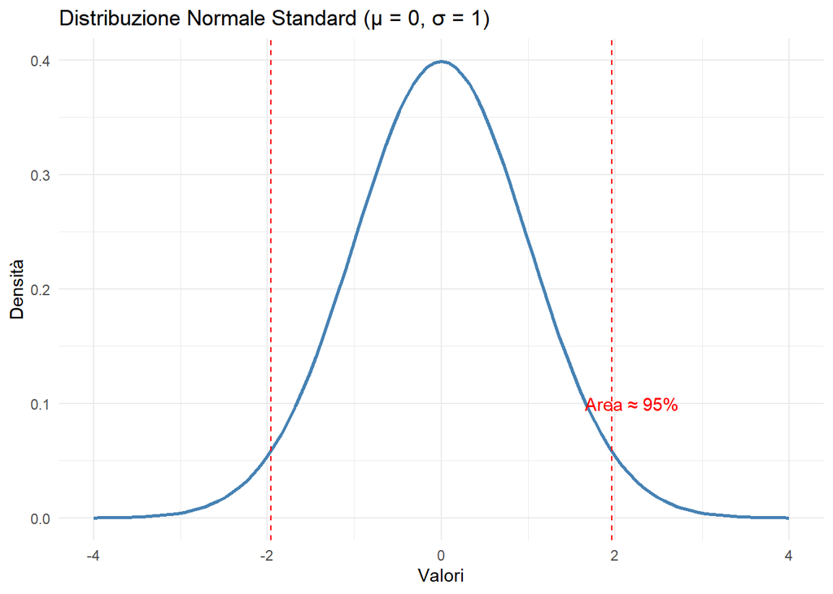

Proprietà della normale

| Proprietà | Dettaglio |
| --- | --- |
| Simmetria | Simmetrica rispetto alla media $\mu$ |
| Unimodale | Ha un solo picco (moda = media = mediana) |
| Asintotica | Le code si avvicinano all’asse x ma non lo toccano mai |
| Area totale sotto la curva | 1 |
| Percentili importanti | 68% dei dati entro 1σ, 95% entro 2σ, 99.7% entro 3σ (regola empirica) |

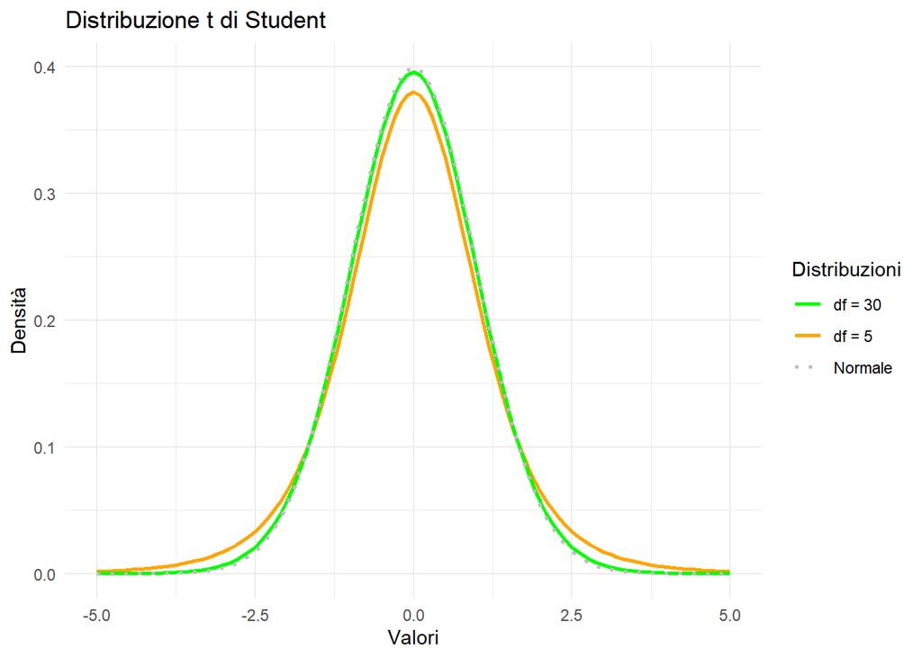

Proprietà della t di Student

| Proprietà | Dettaglio |
| --- | --- |
| Simmetrica | È centrata su 0, come la normale |
| Code più pesanti | Maggiore probabilità di valori estremi rispetto alla normale |
| Dipende da $df = n-1$ | $df=n−1$ Gradi di libertà, variano con la dimensione del campione |
| Converge alla normale | Per $( n \to \infty )$, la distribuzione t diventa una normale standard |
| Varianza | non definita per $df \leq 2$ |

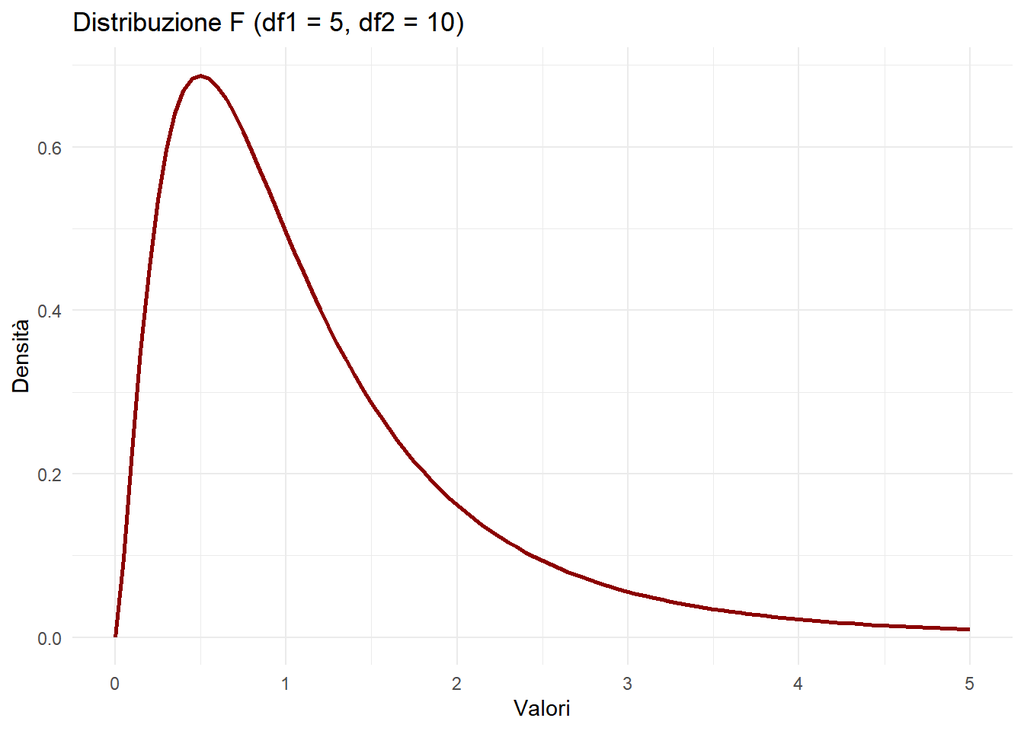

Proprietà della F di Fisher

| Proprietà | Dettaglio |
| --- | --- |
| Dominio | Solo valori positivi: $F ∈ [0, +∞)]$ |
| Asimmetrica | Ha una coda destra lunga, soprattutto per piccoli d.f. |
| Dipende da due d.f. | Numeratore $d_1$, denominatore $d_2$ |
| Media | $\frac{d_2} {d_2 - 2}$, se $d_2 > 2$ |
| Moda | $\frac {(d_1 - 2) d_2}{d_1 (d_2 + 2)}$, se $d_1 > 2$ |
| Varianza | Formula complessa; esiste solo per $d_2 > 4$ |
| Non simmetrica | Spostata a destra; con d.f. grandi tende alla distribuzione normale |

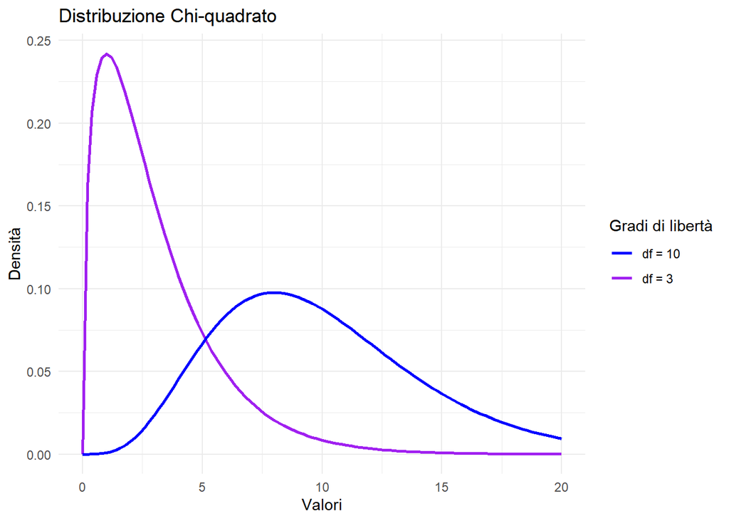

Proprietà della Chisq

| Proprietà | Dettaglio |
| --- | --- |
| Dominio | Solo valori positivi: $\chi^2 \in [0, +\infty)$ |
| Asimmetrica | Distribuzione asimmetrica a destra, più simmetrica all’aumentare dei gradi di libertà |
| Dipende da d.f. | Unico parametro: gradi di libertà $k$ |
| Media | $\mu = k$ |
| Varianza | $\sigma^2 = 2k$ |
| Moda | $k - 2$, se $k \geq 2$ |
| Simmetria | Per $k > 30$ tende alla normale: $\mathcal{N}(k, 2k)$ |
| Somma di quadrati | $\chi^2 = \sum_{i=1}^{k} Z_i^2$, con $Z_i \sim \mathcal{N}(0, 1)$ |

## ASSUNTI DEL MODELLO DI REGRESSIONE

Come tutti i modelli statistici, anche quello di regressione lineare si basa su una serie di assunti che devono essere rispettati ovvero:

- **Indipendenza dei predittori dall’errore.** Le X sono misurate senza errore. Tale assunto è evidente nei disegni sperimentali in cui i valori dei predittori sono sotto il diretto controllo dello sperimentatore. Nel resto dei casi i valori delle X sono ottenuti come risultato di un campionamento, pertanto questa assunzione implica che i predittori e gli errori siano indipendenti nella popolazione da cui vengono estratti.
- **Indipendenza delle osservazioni.** Tutte le coppie di errori $\varepsilon i$ ed $\varepsilon j$ sono tra loro indipendenti per ogni $i = j$. Detto in altri termini significa semplicemente che le osservazioni sono state campionate in modo indipendente l’una dall’altra.
- **Linearità.** Il valore atteso dell’errore per un dato valore di X2 è zero: $E(\varepsilon i) = E(\varepsilon|xi) = 0$. In pratica significa che il valore atteso della variabile dipendente, $E(Y)$, è una funzione lineare del predittore.
- **Normalità.** Gli errori sono distribuiti normalmente: $\varepsilon i ∼ N(0,σ2)$. Questo implica che anche la distribuzione di yi sia normale con media pari a $\beta0 + \beta xi$.
- **Varianza costante.** La varianza degli errori è costante per qualunque valore di X : $V(\varepsilon|xi) = σ2$. Anche in questo caso la varianza costante negli errori implica valori costanti anche della variabile Y per ciascun valore dato di X.

## Interpretazione test parametrici

| **Test** | **Tipo di Dato** | **Assunti** | **Verifica Assunti** | **Interpretazione (p-value)** |
| --- | --- | --- | --- | --- |
| t-test indipendenti | Continua | Normalità, omogeneità varianze, indipendenza | Shapiro-Wilk, Levene | p < 0.05: differenza tra gruppi |
| t-test appaiati | Continua (paired) | Normalità delle differenze | Shapiro-Wilk su differenze | p < 0.05: differenza tra condizioni |
| ANOVA a una via | Continua + gruppi | Normalità, omogeneità varianze, indipendenza | Shapiro-Wilk, Levene, Bartlett | p < 0.05: almeno un gruppo differente |
| ANOVA a due vie | Continua + 2 fattori | Come sopra + assenza di interazioni spurie | Verifica grafica, Levene, Bartlett | p < 0.05: effetti principali/interazione significativi |
| MANOVA | Continua multivariata | Multinormalità, omogeneità covarianze, assenza multicollinearità | Box’s M, grafici, Bartlett | p < 0.05: almeno una differenza multivariata tra i gruppi |
| Regressione lineare semplice | Continua | Linearità, normalità residui, omoscedasticità, indipendenza residui | Q-Q plot, Breusch-Pagan, Durbin-Watson, scatter plot | p < 0.05: predittore significativo |
| Regressione multipla | Continua | Idem sopra + no multicollinearità | VIF, Condition Index | p < 0.05: almeno un predittore è significativo |
| Test F per varianze | Continua | Normalità, indipendenza | Shapiro-Wilk, disegno | p < 0.05: varianze significativamente diverse |
| Z-test | Continua, n > 30 | Conoscenza σ pop, normalità (o n grande) | Controllo teorico | p < 0.05: differenza tra media campione e popolazione |

## Interpretazione test NON parametrici

| **Test** | **Tipo di Dato** | **Assunti** | **Verifica Assunti** | **Interpretazione (p-value)** |
| --- | --- | --- | --- | --- |
| Mann-Whitney U | Ordinale o continua non normale | Forma simile distribuzioni, indipendenza | Boxplot, istogrammi | p < 0.05: distribuzioni significativamente diverse |
| Wilcoxon signed-rank | Paired non normali | Simmetria differenze, osservazioni appaiate | Boxplot delle differenze | p < 0.05: differenza significativa tra condizioni |
| Kruskal-Wallis | Ordinale / continua | Forma simile, indipendenza | Istogrammi, boxplot | p < 0.05: almeno un gruppo differente |
| Friedman test | Misure ripetute ordinali | Osservazioni appaiate | Disegno sperimentale | p < 0.05: almeno una condizione differente |
| Spearman’s rho | Ordinale o continua | Relazione monotona, indipendenza | Scatterplot, test monotonia | p < 0.05: correlazione significativa |
| Kendall’s tau | Ordinale, piccoli campioni | Relazione monotona, indipendenza | Scatterplot, test monotonia | p < 0.05: correlazione significativa |
| Chi-quadro (indipendenza) | Categoriale | Frequenze attese ≥ 5, indipendenza | Tabella contingenza, conteggi | p < 0.05: associazione significativa |
| Test esatto di Fisher | Categoriale, n piccolo | Frequenze molto basse, 2x2 | Tabella contingenza | p < 0.05: associazione significativa |
| McNemar | Categoriale paired | Osservazioni appaiate | Tabella 2x2, differenze discordanti | p < 0.05: cambiamento significativo pre/post |

## Interpretazione test per assunti

| **Test** | **Assunto** | **Uso** | **Interpretazione (p-value)** |
| --- | --- | --- | --- |
| Shapiro-Wilk / Kolmogorov | Normalità | Normalità delle variabili o residui | p < 0.05: dati NON normali |
| Levene / Bartlett | Omogeneità varianze | Test ANOVA, t-test indipendenti | p < 0.05: varianze NON omogenee |
| Mauchly | Sfericità | Misure ripetute | p < 0.05: sfericità VIOLATA |
| Breusch-Pagan / White | Omoscedasticità residui | Regressione | p < 0.05: eteroscedasticità presente |
| Durbin-Watson | Indipendenza residui | Serie temporali / regressione | ≠ 2: autocorrelazione presente |
| VIF / Tolerance | Multicollinearità | Regressione multipla | VIF > 10: multicollinearità problematicamente alta |

## Interpretazione path diagram modelli multilivello

Tabella riassuntiva dei parametri SEM da stimare

| Parametro | Indicatore | Descrizione | Numero |
| --- | --- | --- | --- |
| Regressioni (β) | → freccia continua | Effetto diretto da un predittore a una variabile dipendente | 1 per freccia |
| Covarianze (φ) | ↔︎ freccia discontinua bidirezionale | Relazione simmetrica tra esogene (non causale) | 1 per coppia |
| Varianze d’errore (ψ) | Archi su se stessi | Varianza del residuo per ogni variabile endogena | 1 per endogena |
| Intercette | Non visibili se dati centrati | Valore atteso delle endogene (se stimato) | 1 per endogena |
| Medie (μ) | Non visibili | Media delle esogene (se stimata) | 1 per esogena |

## Matrice PSI (Ψ) - effetti casuali

```
            (Intercept)         x1         x2
(Intercept)  0.90918802 0.02800478 0.01852495
x1           0.02800478 0.98446597 0.12092732
x2           0.01852495 0.12092732 0.45868029
```

- 🔍 Interpreta la matrice

**Diagonale** (verso sinistra) - varianze (quanto variano gli effetti casuali per intercetta, x1, x2)

**Fuori diagonale** - covarianze (come variano insieme gli effetti nei gruppi)

## Lettura output

### Regressione lineare

```
Call:
lm(formula = weight ~ height, data = dati)

Residuals:
    Min      1Q  Median      3Q     Max
-8.5830 -3.0758 -0.3937  2.6129 14.8068

Coefficients:
            Estimate Std. Error t value Pr(>|t|)
(Intercept) -21.7935     8.2313  -2.648  0.00945 **
height        0.9634     0.0481  20.031  < 2e-16 ***
---
Signif. codes:  0 '***' 0.001 '**' 0.01 '*' 0.05 '.' 0.1 ' ' 1

Residual standard error: 4.368 on 98 degrees of freedom
Multiple R-squared:  0.8037,    Adjusted R-squared:  0.8017
F-statistic: 401.2 on 1 and 98 DF,  p-value: < 2.2e-16
```

**Mostra interpretazione dettagliata**

### Analisi della varianza

```
            Df Sum Sq Mean Sq F value   Pr(>F)
group        2   1720   860.3   31.37 5.53e-11 ***
Residuals   87   2386    27.4
---
Signif. codes:  0 '***' 0.001 '**' 0.01 '*' 0.05 '.' 0.1 ' ' 1
```

**Mostra interpretazione dettagliata**

## 🧾 Interpretazione dell’Output

- **Obiettivo**: verificare se almeno un gruppo ha una media significativamente diversa.
- **Formula**: `values ~ group` confronta le medie dei gruppi A, B e C.
- **Gradi di libertà (DF)**:
  - *Tra gruppi*: `k - 1` → 3 − 1 = 2
  - *Entro gruppi (residuali)*: `n - k` → 90 − 3 = 87
- **Somma dei quadrati (Sum Sq)**:
  - *Between Groups*: variabilità spiegata dalle differenze tra le medie
  - *Residuals*: variabilità interna ai gruppi
- **Media dei quadrati (Mean Sq)**: Sum Sq / DF
- **F-value**: rapporto tra varianza spiegata e residua
- **Pr(>F)**:
  - Se < 0.05 → almeno un gruppo ha media significativamente diversa
  - Se > 0.05 → nessuna differenza significativa

### Confronto tra modelli (AIC)

```
Global model call: lm(formula = mpg ~ wt + hp + qsec + drat, data = mtcars)
---
Model selection table
   (Intrc)  drat       hp    qsec     wt df   logLik   AIC delta weight
11  37.230       -0.03177         -3.878  4  -74.326 156.7  0.00  0.181
14  11.390 1.656           0.9462 -4.398  5  -73.352 156.7  0.05  0.176
13  19.750                 0.9292 -5.048  4  -74.360 156.7  0.07  0.175
12  29.390 1.615 -0.03223         -3.228  5  -73.366 156.7  0.08  0.174
16  19.260 1.657 -0.01784  0.5275 -3.708  6  -72.509 157.0  0.36  0.151
15  27.610       -0.01782  0.5108 -4.359  5  -73.571 157.1  0.49  0.141
9   37.290                        -5.344  3  -80.015 166.0  9.38  0.002
10  30.290 1.442                  -4.783  4  -79.484 167.0 10.32  0.001
4   10.790 4.698 -0.05179                 4  -80.752 169.5 12.85  0.000
8   17.740 4.429 -0.05797 -0.2841         5  -80.561 171.1 14.47  0.000
7   48.320       -0.08459 -0.8866         4  -86.170 180.3 23.69  0.000
3   30.100       -0.06823                 3  -87.619 181.2 24.59  0.000
6  -27.840 7.309           1.2130         4  -88.026 184.1 27.40  0.000
2   -7.525 7.678                          3  -92.400 190.8 34.15  0.000
5   -5.114                 1.4120         3  -99.294 204.6 47.94  0.000
1   20.090                                2 -102.378 208.8 52.10  0.000
Models ranked by AIC(x)
```

**Mostra interpretazione dettagliata**

### Chisq Test per modelli annidati

```
Data: sleepstudy
Models:
m1: Reaction ~ 1 + (1 | Subject)
m2: Reaction ~ Days + (1 | Subject)
m3: Reaction ~ Days + I(Days^2) + (1 | Subject)
m4: Reaction ~ Days + I(Days^2) + I(Days^3) + (1 | Subject)
m5: Reaction ~ Days + I(Days^2) + I(Days^3) + I(Days^4) + (1 | Subject)
   npar    AIC    BIC  logLik deviance    Chisq Df Pr(>Chisq)
m1    3 1916.5 1926.1 -955.27   1910.5
m2    4 1802.1 1814.8 -897.04   1794.1 116.4624  1     <2e-16 ***
m3    5 1802.9 1818.9 -896.47   1792.9   1.1349  1     0.2867
m4    6 1804.9 1824.1 -896.47   1792.9   0.0094  1     0.9226
m5    7 1806.3 1828.6 -896.14   1792.3   0.6599  1     0.4166
---
Signif. codes:  0 '***' 0.001 '**' 0.01 '*' 0.05 '.' 0.1 ' ' 1
```

**Mostra interpretazione dettagliata**

## 🧾 Interpretazione dell’Output

- Sono stati confrontati 5 modelli misti annidati:
  - Tutti includono un termine casuale per il soggetto (`(1 | Subject)`).
  - Ogni modello aggiunge progressivamente effetti fissi: `Days`, `Days^2`, ecc.
- La tabella mostra:
  - **AIC, BIC**: criteri di bontà del modello; valori più bassi sono migliori.
  - **logLik**: log-verosimiglianza del modello.
  - **Chisq**: statistica del test del rapporto di verosimiglianza (LRT).
  - **Df diff**: differenza nei gradi di libertà tra i modelli.
  - **Pr(>Chisq)**: p-value del test LRT.
- Se il p-value < 0.05 → l’aggiunta della nuova variabile migliora significativamente il modello.
- È importante usare `REML = FALSE` per confronti validi tra modelli con effetti fissi diversi.
- L’ultimo modello con miglioramento significativo e AIC basso può essere selezionato come finale.

### Bayes Factor Analysis

```
Bayes factor analysis
--------------
[1] wt + hp : 17.27075 ±0.01%

Against denominator:
  mpg ~ wt
---
Bayes factor type: BFlinearModel, JZS
```

**Mostra interpretazione dettagliata**

## 🧾 Interpretazione dell’Output

- Sono stati confrontati due modelli:
  - **BF1**: mpg ~ wt
  - **BF2**: mpg ~ wt + hp
- Il **Bayes Factor (BF)** confronta direttamente la probabilità dei dati sotto i due modelli.
- Valore calcolato: `BF2 / BF1`
  - Se **BF > 1** → i dati supportano di più il secondo modello.
  - Se **BF < 1** → i dati supportano di più il primo modello.
- **Interpretazione standard del BF**:
  - 1–3: evidenza debole
  - 3–10: evidenza moderata
  - (>10): evidenza forte a favore del modello al numeratore
- Il BF è una misura continua della forza di evidenza, a differenza del p-value che si basa su soglie arbitrarie.

### Log Relative Evidence tra modelli (Bayes Factor)

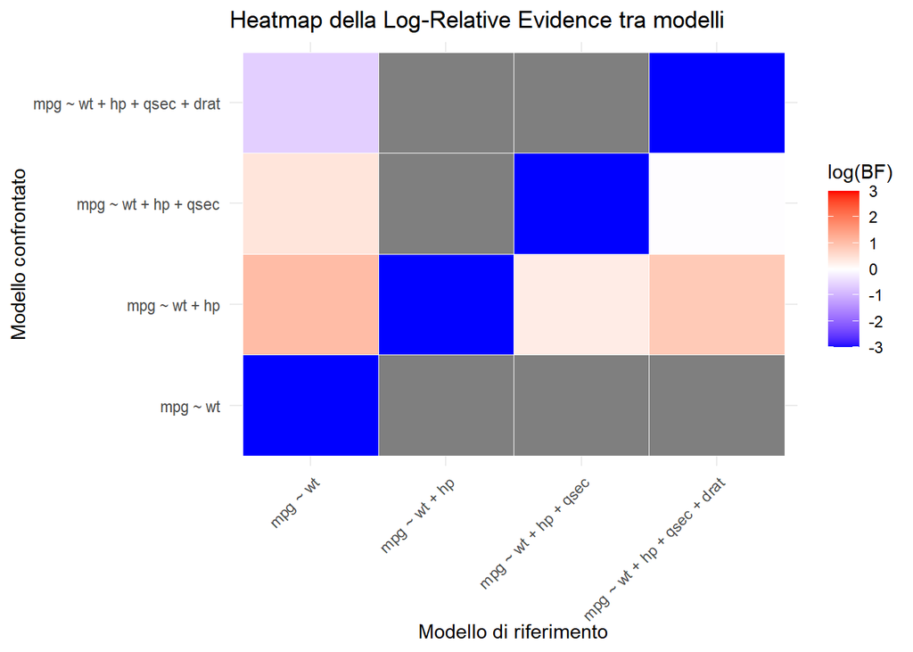

**Mostra interpretazione dettagliata**

## 🧾 Interpretazione dell’Output

- Ogni cella della heatmap rappresenta il **logaritmo del Bayes Factor** tra due modelli specifici.
- Il colore indica la forza dell’evidenza:
  - **Rosso**: evidenza a favore del modello sulla riga rispetto a quello sulla colonna.
  - **Blu**: evidenza a favore del modello sulla colonna rispetto a quello sulla riga.
  - **Bianco**: evidenza neutra o trascurabile.
- La scala dei colori è limitata tra -3 e 3 per facilitare l’interpretazione visiva.
- Questo tipo di visualizzazione consente un confronto diretto e intuitivo tra tutti i modelli considerati.